# Assignment 8

Manuela Giansante

2023-04-30

```r
library(fpp3)
library(dplyr)
library(urca)
library(forecast)
library(cowplot)
```

## EXERCISE 3: Choose a series from us_employment, the total employment in different industries in the United States.

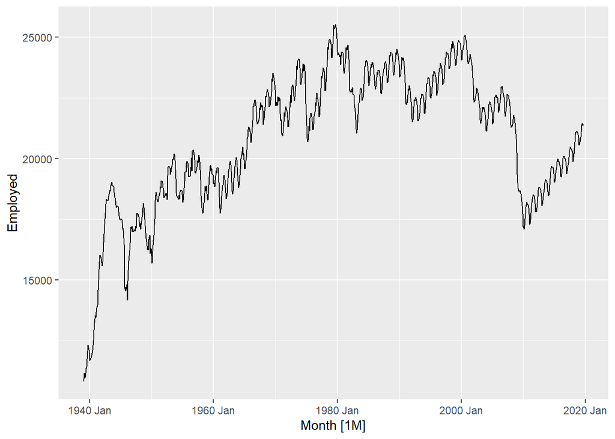

```r
us_employment %>% filter(Title=="Goods-Producing")%>% autoplot(Employed)
```

The data is monthly recorded, there is space for seasonality, but of course we also need to consider that maybe cycles are a slightly more dominant feature in this kind of data, Employment is heavily influenced by the business cycle, which as any cycle is not regular in its intervals. The 2008 downward shock is present, followed by a quite steep and regular increase. The trend can be considered increasing, but not in a linear way. We can consider it being stochastic, so it is influenced by “random” shocks.

### 1. Produce an STL decomposition of the data and describe the trend and seasonality.

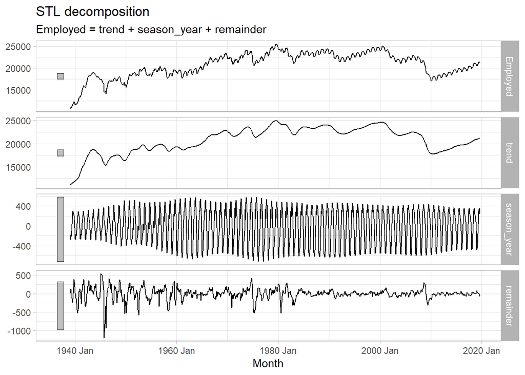

```r
# object creation
ts1<-us_employment %>% filter(Title=="Goods-Producing")%>% select(Employed)

# decomposition with default function
ts1 %>%
  model(STL(Employed))%>%
  components()%>%
  autoplot()+theme_light()
```

We see that the trend is not linear, including the cycles. The seasonal undulation is not constant in its amplitude, so that is something we need to take into account, but also the variance does not increase with time. The remainder seems random enough, still it retains the movements of some of the bigger shocks. We force the seasonal component to be constant:

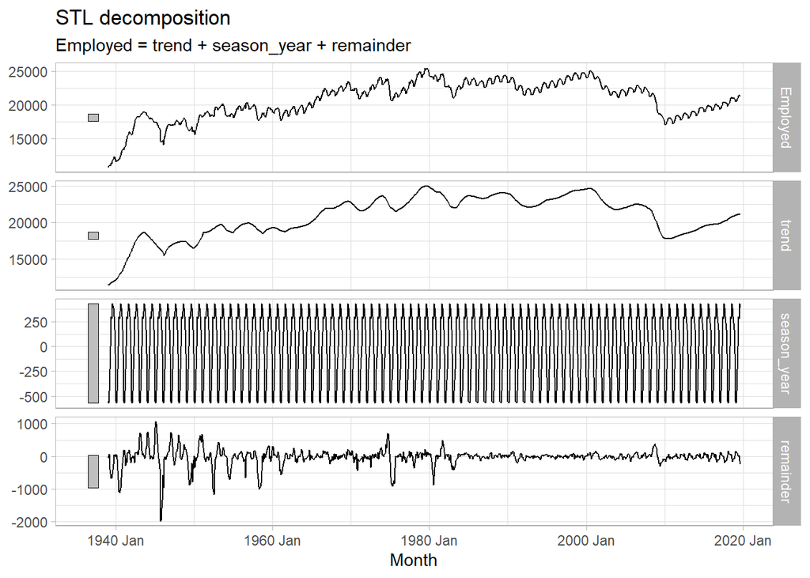

```r
ts1 %>%
  model(STL(Employed~ season(window="periodic"), robust=TRUE))%>%
  components()%>%
  autoplot()+theme_light()
```

### 2. Do the data need transforming? If so, find a suitable transformation.

We handle the that variability of the seasonal element we observed above.

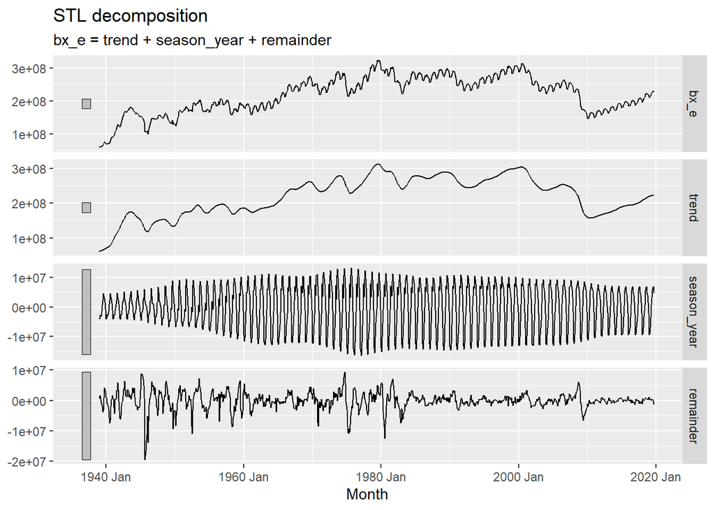

```r
# Optimal value of lambda
lambda <- ts1 %>%
  features(Employed, features = guerrero) %>%
  pull(lambda_guerrero)

ts1_bxcx<- ts1%>% mutate(bx_e = box_cox(Employed, lambda))%>% as_tsibble()
ts1_bxcx %>% model(STL(bx_e))%>%components()%>% autoplot()
```

The logarithm transformation, which we do not report here, did not help the change in variation over time. We let the Guerrero feature chose the optimal value of lambda for the Box-Cox transformation.

### 3. Are the data stationary? If not, find an appropriate differencing which yields stationary data.

The data is not stationary, it has a strong seasonality factor. More over the increasing trend is present as much as it is not necessarily linear it its incline. The cycles do not depend on time, but for the seasonality that is the case.

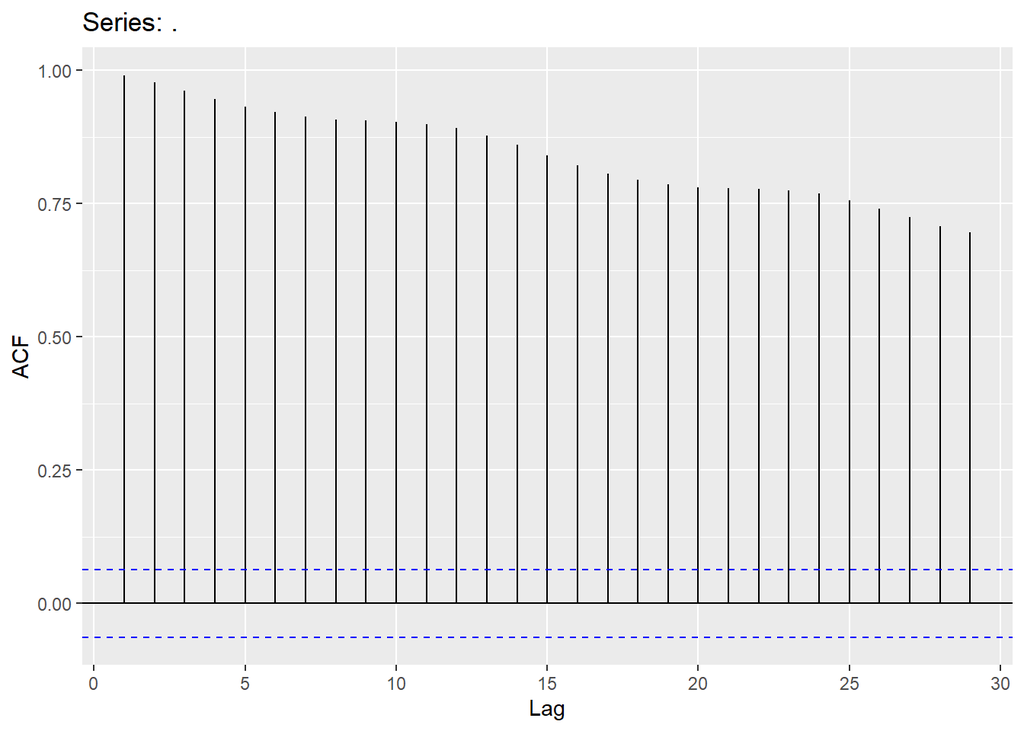

```r
# ACF and PACF
ts1_bxcx$bx_e %>% ggAcf()
```

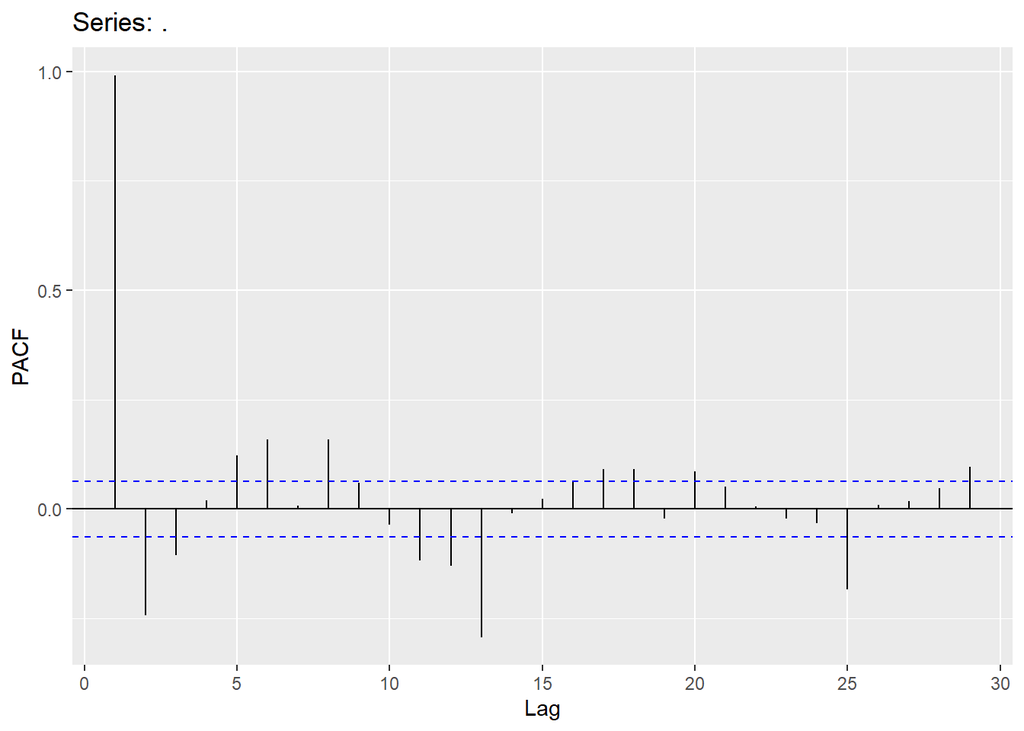

```r
ts1_bxcx$bx_e %>% ggPacf()
```

```r
# What unitroot_ndiffs() suggests:
ts1_bxcx %>% features(bx_e, unitroot_ndiffs)
```

```
## # A tibble: 1 x 1
##   ndiffs
##    <int>
## 1      1
```

```r
ts1_bxcx %>% features(bx_e, unitroot_nsdiffs)
```

```
## # A tibble: 1 x 1
##   nsdiffs
##     <int>
## 1       1
```

The ACF decays very slowly there is long-term dependency within the series. Moreover the PACF plot is sinusoidal in appearance, with some significant spikes. The single spike in PACF at lag 1, indicates that all higher-order autocorrelations are effectively explained by lag1 autocorrelation.

The ndiffs() and nsdiffs() function suggest to differentiate both for the trend and both for seasonality.

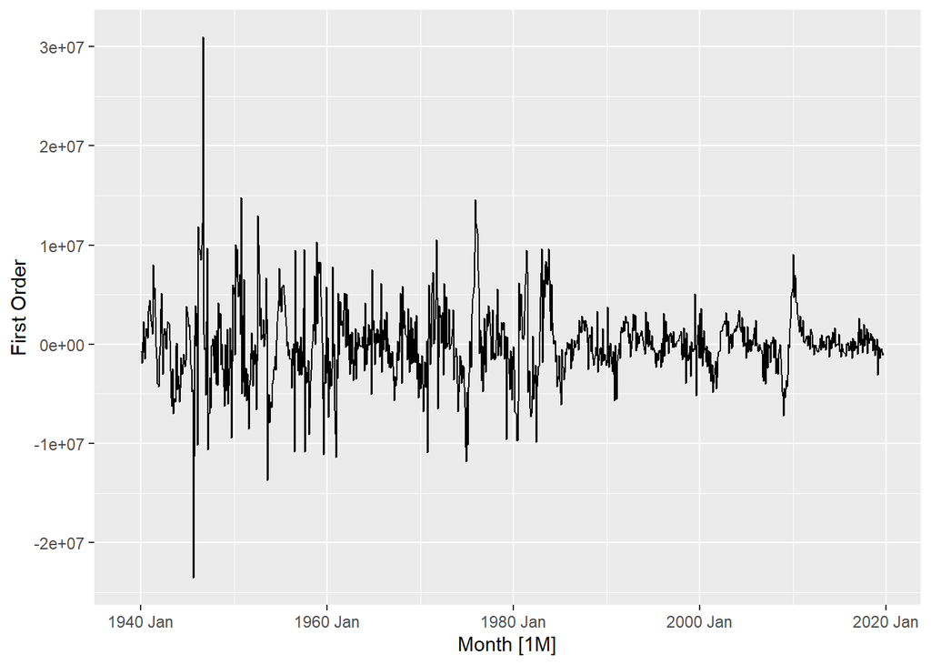

```r
ts1_bxcx%>% select(bx_e) %>% transmute("First Order"=difference(difference(bx_e),12))%>% autoplot()
```

```r
ts1_bxcx%>% select(bx_e) %>% mutate(Diff = (difference(difference(bx_e),12)))%>% features(Diff, unitroot_kpss)
```

```
## # A tibble: 1 x 2
##   kpss_stat kpss_pvalue
##       <dbl>       <dbl>
## 1   0.00899         0.1
```

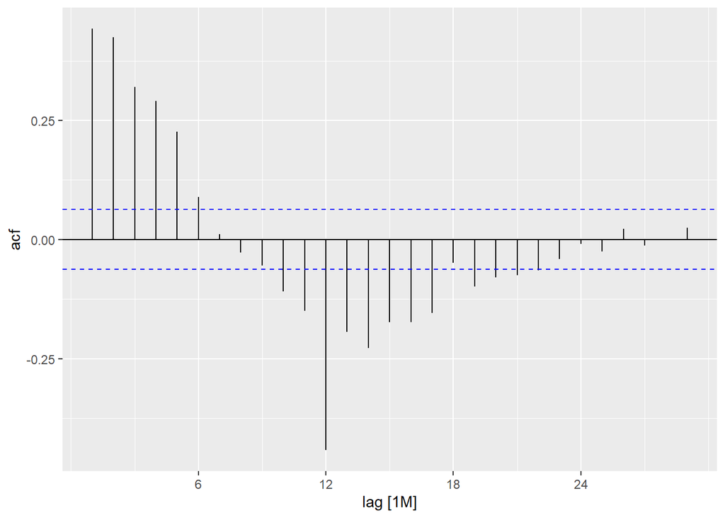

```r
ts1_bxcx%>% ACF(difference(difference(bx_e),12)) %>% autoplot()
```

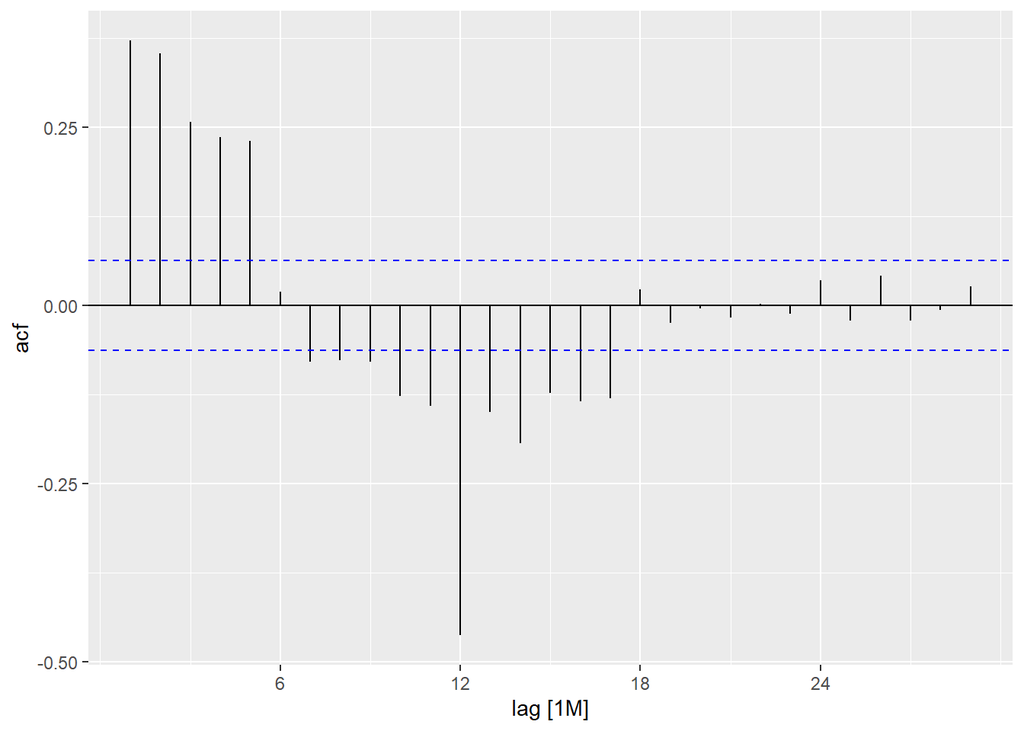

```r
# we still try one last time with simply logged data
ts1_bxcx%>% ACF(difference(difference(log(Employed)),12)) %>% autoplot()
```

The ACF plot still shows some autocorrelation, which seems not random enough for it to be written off as such. This Seasonal Persistence might be due some external factors(not the series itself), so at we could do is investigate what other factors influence Employment in the Goods-Producing sector and run other methods (e.g. VAR). The data (after being box-cox transformed and differentiated) passes the KPSS test, as stationary. When plotted out the data series in fact does look stationary.

### 4. Identify several ARIMA models that might be useful in describing the time series. Which of your models is the best according to their AICc values?

Given that the data needs differencing for sure d=1 will be needed. There is seasonality so the model will have to be a seasonal ARIMA. We re-propose the ACF and PACF of the non differentiated data for reference:

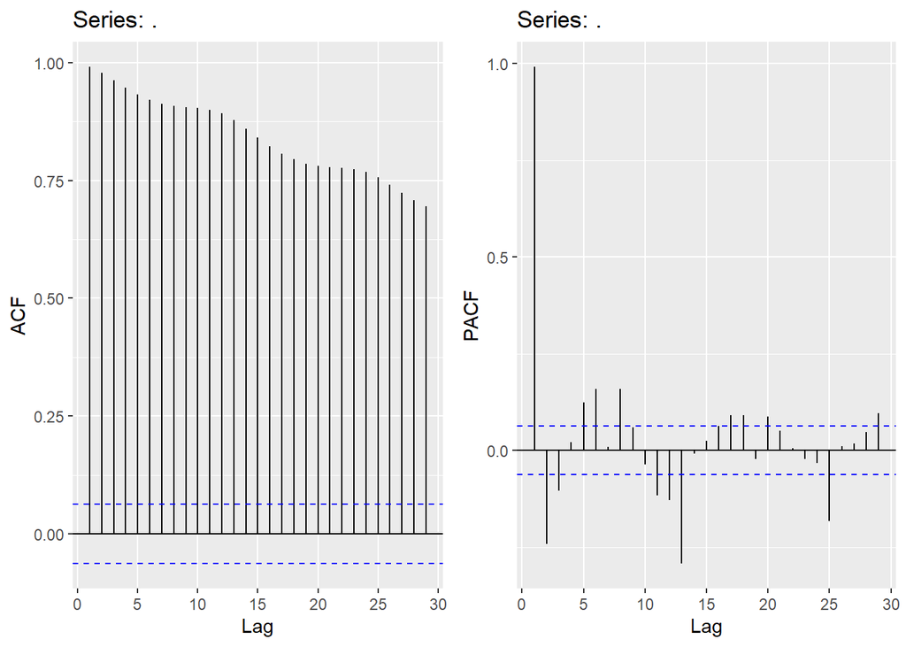

```r
ACF<-ts1_bxcx$bx_e %>% ggAcf()
PACF<-ts1_bxcx$bx_e %>% ggPacf()
plot_grid(ACF,PACF)
```

Given the spike in PACF at lag1 we should consider a AR(1).This implies that in the autoregressive model you should have 1 parameter, $y_t$ is regressed on lag 1 of series y. To be noted is that also lag 2 and 3 are significant, but maybe that would risk an over-parametrisation of the model, over-fitting the data. We will run a seasonal AR(1) and observe the coefficients.

```r
Fit2 <- ts1_bxcx %>% model(ARIMA(bx_e ~ pdq(1,0,0)))
report(Fit2)
```

```
## Series: bx_e
## Model: ARIMA(1,0,0)(1,1,0)[12]
##
## Coefficients:
##          ar1     sar1
##       0.9885  -0.4369
## s.e.  0.0046   0.0289
##
## sigma^2 estimated as 1.15e+13:  log likelihood=-15749.77
## AIC=31505.54   AICc=31505.57   BIC=31520.13
```

We will fit seasonal ARIMA(1,1,1), seasonal ARIMA(2,1,0) and, seasonal ARIMA (1,1,0): We do not attempt a d=2 because we know that it is not necessary in most cases.

```r
#seasonal ARIMA(1,1,1)
Fit3 <- ts1_bxcx %>% model(ARIMA(bx_e ~ pdq(1,1,1)))
report(Fit3)
```

```
## Series: bx_e
## Model: ARIMA(1,1,1)(0,1,1)[12]
##
## Coefficients:
##          ar1      ma1     sma1
##       0.8391  -0.5205  -0.7726
## s.e.  0.0285   0.0426   0.0233
##
## sigma^2 estimated as 6.844e+12:  log likelihood=-15487.58
## AIC=30983.16   AICc=30983.2   BIC=31002.61
```

```r
# seasonal ARIMA(2,1,0)
Fit4 <- ts1_bxcx %>% model(ARIMA(bx_e ~ pdq(2,1,0)))
report(Fit4)
```

```
## Series: bx_e
## Model: ARIMA(2,1,0)(0,1,1)[12]
##
## Coefficients:
##          ar1     ar2     sma1
##       0.3178  0.2725  -0.7724
## s.e.  0.0311  0.0312   0.0238
##
## sigma^2 estimated as 6.883e+12:  log likelihood=-15490.31
## AIC=30988.63   AICc=30988.67   BIC=31008.08
```

```r
#seasonal ARIMA (1,1,0)
Fit5 <- ts1_bxcx %>% model(ARIMA(bx_e ~ pdq(1,1,0)))
report(Fit5)
```

```
## Series: bx_e
## Model: ARIMA(1,1,0)(0,1,2)[12]
##
## Coefficients:
##          ar1     sma1     sma2
##       0.4320  -0.7482  -0.0528
## s.e.  0.0293   0.0313   0.0311
##
## sigma^2 estimated as 7.405e+12:  log likelihood=-15525.64
## AIC=31059.28   AICc=31059.32   BIC=31078.73
```

In terms of AICc the best performing model is ARIMA(1,1,1). In the coefficient of am1 there is no unit root, we add 1 MA term and see if that improves our model or not.

```r
#seasonal ARIMA(1,1,2)
Fit6 <- ts1_bxcx %>% model(ARIMA(bx_e ~ pdq(1,1,2)))
report(Fit6)
```

```
## Series: bx_e
## Model: ARIMA(1,1,2)(0,1,1)[12]
##
## Coefficients:
##          ar1      ma1     ma2     sma1
##       0.8056  -0.5165  0.0736  -0.7694
## s.e.  0.0373   0.0488  0.0348   0.0237
##
## sigma^2 estimated as 6.822e+12:  log likelihood=-15485.46
## AIC=30980.93   AICc=30980.99   BIC=31005.24
```

Still there is not unit root in the coefficient of the MA part of the model, we keep the MA parameter. Moreover the AICc value has decreased as well. We try one last model, even if ARIMA(2,1,2) seems to present un-necessary complexity.

```r
#seasonal ARIMA(1,1,2)
Fit7 <- ts1_bxcx %>% model(ARIMA(bx_e ~ pdq(2,1,2)))
report(Fit7)
```

```
## Series: bx_e
## Model: ARIMA(2,1,2)(0,1,1)[12]
##
## Coefficients:
##          ar1     ar2     ma1      ma2     sma1
##       0.1280  0.5745  0.1667  -0.2968  -0.7717
## s.e.  0.3821  0.3328  0.3964   0.2415   0.0238
##
## sigma^2 estimated as 6.822e+12:  log likelihood=-15485.03
## AIC=30982.06   AICc=30982.15   BIC=31011.24
```

The sum of the AR coefficients is not close to 1, therefore this adding of an AR term is not the best in terms of complexity but also it is not over-fitting the data. The AICc is higher than Fit6, our selected model is SARIMA(1,1,2), or better seasonal ARIMA (1,1,2)(0,1,1).

### 5. Estimate the parameters of your best model and do diagnostic testing on the residuals. Do the residuals resemble white noise? If not, try to find another ARIMA model which fits better.

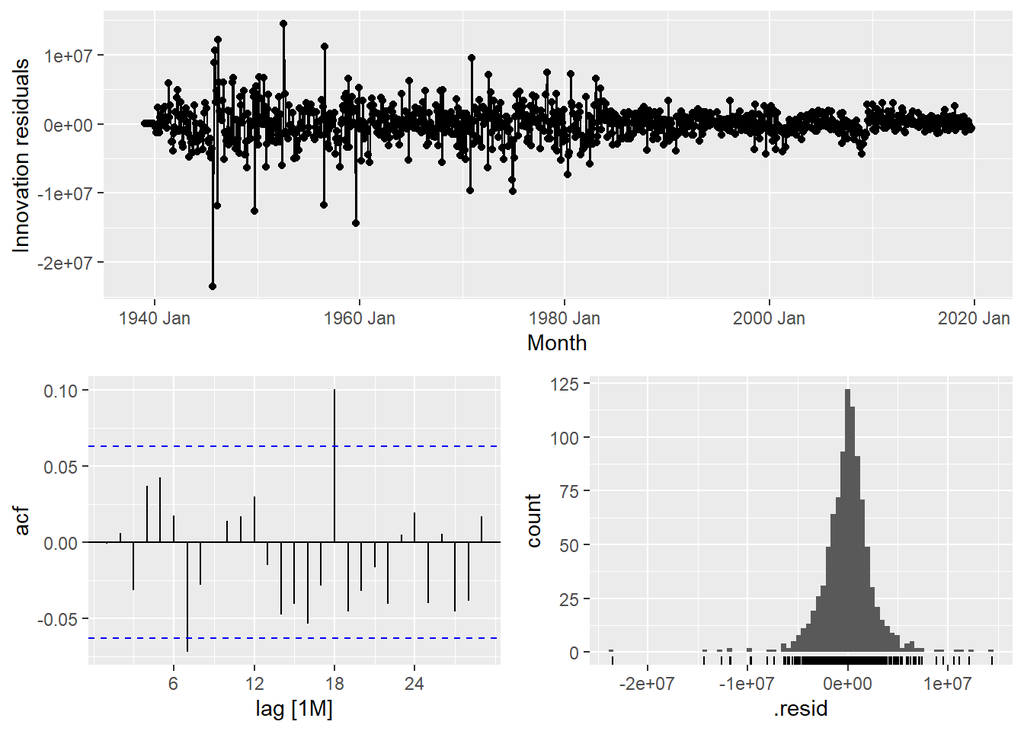

```r
# Residuals of ARIMA(1,1,2)(0,1,1)
gg_tsresiduals(Fit6)
```

The residuals appear normal and uncorrelated enough, the higher order lags might show autocorrelation because of outside factors that might not be found in the series itself. We check for unit roots:

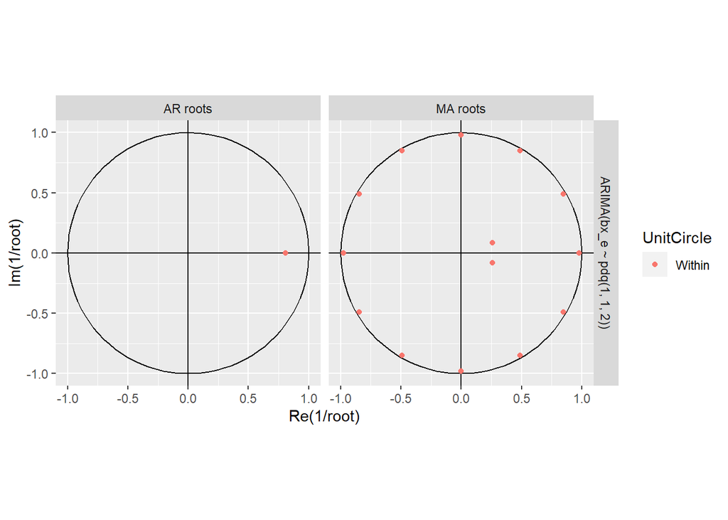

```r
gg_arma(Fit6)
```

The inverse roots for the AR term lies inside (therefore the not inverse are outside of it). The seasonal MA roots are inside but on the border, might signal some instability in the forecast.

### 6. Forecast the next 3 years of data. Get the latest figures to check the accuracy of your forecasts.

```r
#divide set into training and validation set
train<- ts1_bxcx[1:932,]
val<- ts1_bxcx[933:969,]

# Train the model
Fit6_t <- train %>% model("fit"=ARIMA(bx_e ~ pdq(1,1,2)))
report(Fit6_t)
```

```
## Series: bx_e
## Model: ARIMA(1,1,2)(0,1,1)[12]
##
## Coefficients:
##          ar1      ma1     ma2     sma1
##       0.8052  -0.5167  0.0727  -0.7705
## s.e.  0.0379   0.0495  0.0355   0.0242
##
## sigma^2 estimated as 7.067e+12:  log likelihood=-14902.55
## AIC=29815.09   AICc=29815.16   BIC=29839.21
```

After we have divided the series into sets and trained the model we generate the forecast.

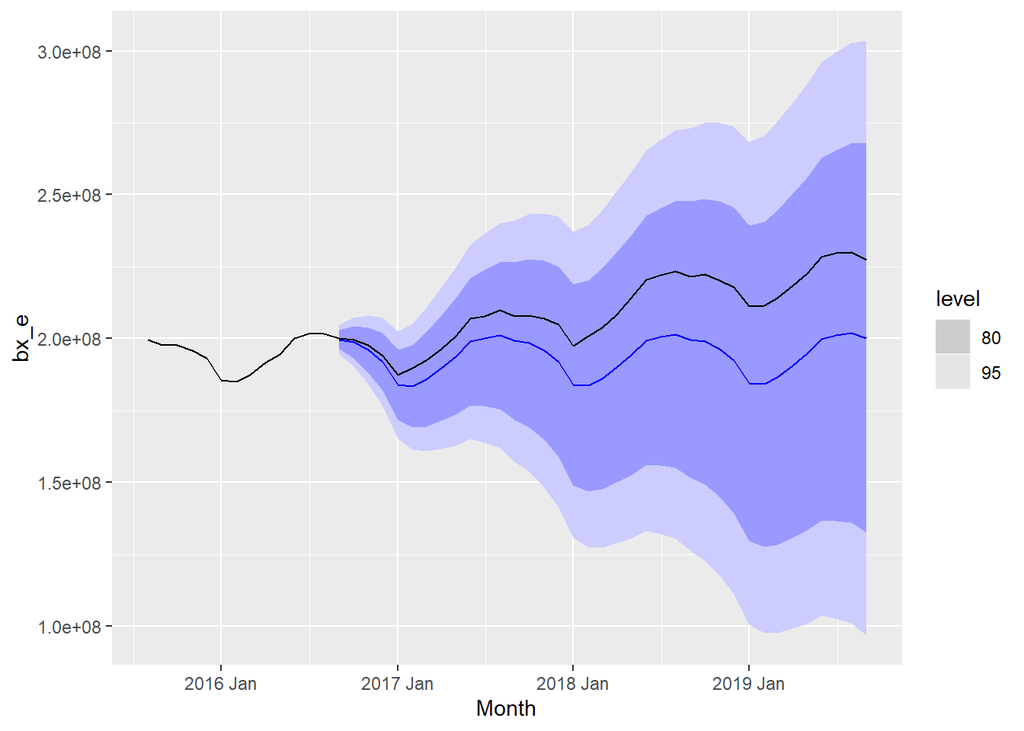

```r
# Forecast
fc<-Fit6_t %>% fabletools::forecast(h=37)

# Plot the forecast
Fit6_t %>% fabletools::forecast(h=37)%>% autoplot(ts1_bxcx[920:969,])
```

```r
# Compute the accuracy measures
fabletools::accuracy(fc,val)
```

```
## # A tibble: 1 x 10
##   .model .type        ME      RMSE       MAE   MPE  MAPE  MASE RMSSE  ACF1
##   <chr>  <chr>     <dbl>     <dbl>     <dbl> <dbl> <dbl> <dbl> <dbl> <dbl>
## 1 fit    Test  16147252. 18700531. 16147252.  7.50  7.50   NaN   NaN 0.936
```

The true data is above the forecast, which given that the data is stochastically driven in its evolution over time, it is coherent with our expectations. The PIs grow in amplitude.

### 7. Eventually, the prediction intervals are so wide that the forecasts are not particularly useful. How many years of forecasts do you think are sufficiently accurate to be usable?

A way of evaluating whether our forecast is accurate enough is to see if the validation series falls within the conifdence intervals of the prediction. From the graph above clearly we can see that that it falls within the 80% PI at all periods. Still we check more in depth:

```r
Confidence <- fc %>% hilo(level = c(80, 95)) %>%
  mutate(
    lower80 = `80%`$lower,
    upper80 = `80%`$upper,
    lower95 = `95%`$lower,
    upper95 = `95%`$upper )

val_trans<- val["bx_e"]

Confidence <- Confidence[c("Month","lower80","upper80","lower95","upper95")]

Comparison <- bind_cols(Confidence, val_trans)

# Is the validation portion of the series inside the
Comparison$in_interval_80 <- ifelse(Comparison$bx_e >= Comparison$lower80 & Comparison$bx_e <= Comparison$upper80, "Yes", "No")
Comparison$in_interval_95 <- ifelse(Comparison$bx_e >= Comparison$lower95 & Comparison$bx_e <= Comparison$upper95, "Yes", "No")

#Check feedback
Comparison$in_interval_80
```

```
##  [1] "Yes" "Yes" "Yes" "Yes" "Yes" "Yes" "Yes" "Yes" "Yes" "Yes" "Yes" "Yes"
## [13] "Yes" "Yes" "Yes" "Yes" "Yes" "Yes" "Yes" "Yes" "Yes" "Yes" "Yes" "Yes"
## [25] "Yes" "Yes" "Yes" "Yes" "Yes" "Yes" "Yes" "Yes" "Yes" "Yes" "Yes" "Yes"
## [37] "Yes"
```

```r
Comparison$in_interval_95
```

```
##  [1] "Yes" "Yes" "Yes" "Yes" "Yes" "Yes" "Yes" "Yes" "Yes" "Yes" "Yes" "Yes"
## [13] "Yes" "Yes" "Yes" "Yes" "Yes" "Yes" "Yes" "Yes" "Yes" "Yes" "Yes" "Yes"
## [25] "Yes" "Yes" "Yes" "Yes" "Yes" "Yes" "Yes" "Yes" "Yes" "Yes" "Yes" "Yes"
## [37] "Yes"
```

References: (https://people.duke.edu/~rnau/411home.htm)